# FigureYa255TIME

**Author(s)**: Xiaofan Lu  
**Reviewer(s)**: Ying Ge, Junyi Shen  
**Date**: 2025-12-03

## 1 Academic Citation

If you use this code in your work or research, we kindly request that you cite our publication:

- Xiaofan Lu, et al. (2025). FigureYa: A Standardized Visualization Framework for Enhancing Biomedical Data Interpretation and Research Efficiency. iMetaMed. https://doi.org/10.1002/imm3.70005

If you use MOVICS in published research, please cite:

- Xiaofan Lu, Jialin Meng, Yujie Zhou, Liyun Jiang, Fangrong Yan, MOVICS: an R package for multi-omics integration and visualization in cancer subtyping, Bioinformatics, Volume 36, Issue 22-23, December 2020, Pages 5539–5541, https://doi.org/10.1093/bioinformatics/btaa1018

If you calculate MeTIL score using PCA in published research, please cite:

- Jeschke J, Bizet M, Desmedt C et al. DNA methylation-based immune response signature improves patient diagnosis in multiple cancers, Journal of Clinical Investigation 2017;127:3090-3102.

If you computational immune microenvironment with 22 CIBERSORT signatures and 2 MCPcounter signatures in published research, please cite:

- Xiao Y, Ma D, Zhao S, et al. Multi-Omics Profiling Reveals Distinct Microenvironment Characterization and Suggests Immune Escape Mechanisms of Triple-Negative Breast Cancer. Clin Cancer Res. 2019

If you use circlize in published research, please cite:

- Gu, Z. circlize implements and enhances circular visualization in R. Bioinformatics 2014.

If you use ComplexHeatmap in published research, please cite:

- Zuguang Gu, et al., Complex heatmaps reveal patterns and correlations in multidimensional genomic data, Bioinformatics, 2016.
- Zuguang Gu. Complex Heatmap Visualization, iMeta, 2022.

## 2 需求描述 Requirement Description

Figure3A的免疫landscape，包括免疫检查点的表达，免疫signature的富集，免疫/基质得分的估计还有甲基化淋巴细胞的定量（Xiaofan Lu老师真是热图高手！）这里主要就是这个DNA甲基化淋巴细胞的定量计算，不知道是怎么来的，所有TCGA数据都可以计算吗？

The immune landscape of Figure 3A includes immune checkpoint expression, immune signature enrichment, immune/stromal score estimation, and methylated lymphocyte quantification (Xiaofan Lu is truly a heatmap expert!). The main goal here is to calculate the quantification of DNA methylated lymphocytes. I’m not sure where this came from, but can this be performed on all TCGA data?

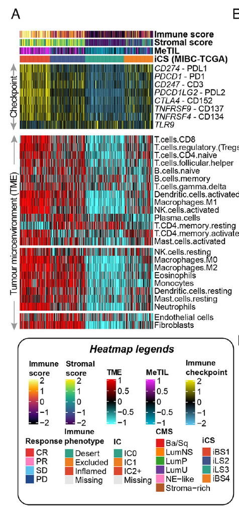

From https://onlinelibrary.wiley.com/doi/10.1002/ctm2.601

FIGURE 3 Differential immune profile across MIBC subtypes and its association with genomic alteration and immunotherapeutic response. (A) Heatmap showing the immune profile in the MIBC-TCGA cohort, with the top panel showing the expression of genes involved in immune checkpoint targets and the bottom panel showing the enrichment level of 24 microenvironment cell types. The immune enrichment score, stromal enrichment score and DNA methylation of tumour-infiltrating lymphocytes (MeTILs) were annotated at the top of the heatmap.

## 3 应用场景 Application Scenarios

Xiaofan Lu写了一个神奇的R包 MOVICS，用自己的数据跑一遍，文章里的key Figure就出来了。 怎么把这些图组织到一起讲故事呢？这篇文章是个很好的应用MOVICS的例子。

根据甲基化计算DNA methylation of tumour-infiltrating lymphocyte (MeTIL)得分，并根据免疫检查点表达和肿瘤免疫微环境富集绘制热图。

我们也曾在FigureYa170ImmuLncRNA里用estimate包计算肿瘤纯度，更新后改用tidyestimate包

例文中很多图我们都实现过，例如：

- Figure 1C的画法可参考FigureYa196PanPie，1DE可参考FigureYa251NPHSurv
- Figure 2A的算法可参考FigureYa249Regulon，B的画法可参考FigureYa248MutLandscape
- Figure 3A由FigureYa255TIME复现，F可参考FigureYa106immunotherapy
- Figure 4B可参考FigureYa12box，F可参考FigureYa162boxViolin，H-L可参考FigureYa35batch_bestSeparation，M 可参考FigureYa144DiagHeatmap或https://mp.weixin.qq.com/s/34WRZRBVPHUNRLlzNH2nzw
- Figure S3批次矫正PCA可参考FigureYa203ComBat
- Figure 4de可参考FigureYa25sankey和FigureYa125Fishertest

Xiaofan Lu wrote an amazing R package called MOVICS. Run it with your own data, and you’ll instantly see the key figures from your article. How can you organize these figures to tell a story? This article provides a great example of MOVICS.

We calculated DNA methylation of tumor-infiltrating lymphocyte (MeTIL) scores based on methylation, and created heatmaps based on immune checkpoint expression and tumor immune microenvironment enrichment.

We previously used the estimate package in FigureYa170ImmuLncRNA to calculate tumor purity, now we use the tidyestimate package.

Many of the figures in the example article:

- For plotting method of Figure 1C, refer to FigureYa196PanPie; for Figure 1DE, refer to FigureYa251NPHSurv
- For algorithm of Figure 2A, refer to FigureYa249Regulon; for plotting method of Figure 2B, refer to FigureYa248MutLandscape
- Figure 3A is reproduced by FigureYa255TIME; for Figure 3F, refer to FigureYa106immunotherapy
- For Figure 4B, refer to FigureYa12box; for Figure 4F, refer to FigureYa162boxViolin; for Figure 4H-L, refer to FigureYa35batch_bestSeparation, for Figure 4M, refer to FigureYa144DiagHeatmap or https://mp.weixin.qq.com/s/34WRZRBVPHUNRLlzNH2nzw
- For Figure S3 batch correction PCA, refer to FigureYa203ComBat
- For Figure 4de, refer to FigureYa25sankey and FigureYa125Fishertest

## 4 环境设置 Environment Setup

```r
source("install_dependencies.R")
```

[output not shown]

```r
library(utils) # 用到read.table函数 # Used for the read.table function
library(GSVA) # 用到GSVA包计算免疫signature的富集分数 # Used to calculate the enrichment scores of immune signatures
library(grDevices) # 用来配色 # Used for color mapping
library(ComplexHeatmap) # 用到里面的pheatmap画图然后拼图，需安装2.8以上版本的ComplexHeatmap # Use the pheatmap function to plot and then assemble the image. You must have ComplexHeatmap version 2.8 or later installed.
library(circlize) # 用来配色 # Used for color mapping
library(viridis) # 用来配色 # Used for color mapping
library(gplots) # 画图用到colorpanel函数 # Used for the colorpanel function in plotting
library(data.table) # 数据读入用到fread函数 # Used for the fread function in data import
library(tidyestimate) # 用来计算immune/stromal得分 (替代旧的estimate包) # Used to calculate immune/stromal scores (replaces old estimate package)
source("annTrackScale.R") # 加载函数，对数值进行标准化并对极端值做截断 # Load the function to normalize and truncate extreme values.
Sys.setenv(LANGUAGE = "en") #显示英文报错信息 # Display English error messages.
options(stringsAsFactors = FALSE) #禁止chr转成factor # Disable conversion of chr values to factors.
```

```r
# 加载自定义函数
standardize.fun <- function(indata=NULL, halfwidth=NULL, centerFlag=TRUE, scaleFlag=TRUE) {
  # First try normal scaling, then handle issues
  outdata <- t(scale(t(indata), center=centerFlag, scale=scaleFlag))

  # Handle cases where scaling produced NA or infinite values
  outdata[is.na(outdata)] <- 0
  outdata[is.infinite(outdata)] <- 0

  # Apply halfwidth truncation if specified
  if (!is.null(halfwidth)) {
    outdata[outdata > halfwidth] <- halfwidth
    outdata[outdata < (-halfwidth)] <- -halfwidth
  }

  # Ensure all values are finite
  outdata[!is.finite(outdata)] <- 0

  return(outdata)
}
```

## 5 利用PCA计算MeTIL得分 Calculate MeTIL score using PCA

```r
# 读入用MOVICS获取的muscle-invasive bladder cancer (MIBC)亚型 # Read in muscle-invasive bladder cancer (MIBC) subtypes obtained using MOVICS
annCol.tcga <- read.table("tcga.mibc.anno.txt",sep = "\t",row.names = 1,check.names = F,stringsAsFactors = F,header = T)

# 读取450K甲基化数据
# 甲基化数据只要用到5个探针的marker就可以，所以这里我的输入数据是简化的，方便传输
# Read 450KB of methylation data
# Methylation data only requires five probe markers, so my input data is simplified for ease of transmission.
meth <- fread("TCGA-BLCA.methylation450.tsv.gz",sep = "\t",check.names = F,stringsAsFactors = F,header = T,data.table = F)
rownames(meth) <- meth[,1]; meth <- as.data.frame(na.omit(meth[,-1]))

# 匹配亚型 # Matching subtypes
colnames(meth) <- substr(colnames(meth), start = 1,stop = 16)
meth <- meth[,which(substr(colnames(meth), 14, 15) == "01")]
# 找到甲基化数据和注释数据中的共同样本
common.samples <- intersect(colnames(meth), rownames(annCol.tcga))
meth <- meth[,common.samples]
annCol.tcga <- annCol.tcga[common.samples, , drop = FALSE]

MeTIL.marker <- c("cg20792833","cg20425130","cg23642747","cg12069309","cg21554552")
meth.metil <- meth[MeTIL.marker,]
MeTIL <- meth[MeTIL.marker,]
MeTIL <- t(scale(t(MeTIL)))

# 计算MeTIL得分 # Calculate MeTIL score
pca.MeTIL <- prcomp(MeTIL,center = F,scale. = F)
MeTIL <- pca.MeTIL$rotation[,1]
annCol.tcga$MeTIL <- MeTIL
```

## 6 计算免疫微环境 Computational immune microenvironment

使用curated免疫签名，包括22个CIBERSORT签名以及2个MCPcounter签名

Using curated immune signatures, including 22 CIBERSORT signatures and 2 MCPcounter signatures

```r
# 加载表达数据 # Load expression data
tpm <- read.table("tcga.mibc.tpm.txt",sep = "\t",row.names = 1,check.names = F,stringsAsFactors = F,header = T)
immune.signature <- read.table("Curated_Immune_Cell_Signature.txt",sep = "\t",check.names = F,stringsAsFactors = F,header = T,row.names = NULL)

# 构建计算GSVA的列表 # Build a list to calculate GSVA
cell.type <- unique(immune.signature$CellType)
immune.sig.ccr <- list()
for (i in cell.type) {
  immune.sig.ccr[[i]] <- immune.signature[which(immune.signature$CellType == i),"Symbol"]
}

# 免疫检查点相关基因 # Immune checkpoint-related genes
imm.targets <- c("CD274","PDCD1","CD247","PDCD1LG2","CTLA4","TNFRSF9","TNFRSF4","TLR9")

# 免疫细胞的排序 # Sorting of immune cells
immune.sig.ccr.order <- c("T.cells.CD8",
                          "T.cells.regulatory..Tregs.",
                          "T.cells.CD4.naive",
                          "T.cells.follicular.helper",
                          "B.cells.naive",
                          "B.cells.memory",
                          "T.cells.gamma.delta",
                          "Dendritic.cells.activated",
                          "Macrophages.M1",
                          "NK.cells.activated",
                          "Plasma.cells",
                          "T.cells.CD4.memory.resting",
                          "T.cells.CD4.memory.activated",
                          "Mast.cells.activated",
                          "NK.cells.resting",
                          "Macrophages.M0",
                          "Macrophages.M2",
                          "Eosinophils",
                          "Monocytes",
                          "Dendritic.cells.resting",
                          "Mast.cells.resting",
                          "Neutrophils",
                          "Endothelial cells",
                          "Fibroblasts")

# 计算immune/stromal得分 # Calculate immune/stromal score
indata <- log2(tpm + 1)
# 保存到文件 # Save to file
#write.table(indata,file = "TCGA_log2TPM_hugo.txt",sep = "\t",row.names = T,col.names = NA,quote = F)

# 使用tidyestimate包计算得分 # Use tidyestimate package to calculate scores
# 转换indata为tidyestimate需要的格式：第一列为基因名 # Convert indata to tidyestimate format: first column contains gene names
indata_for_tidy <- as.data.frame(indata)
indata_for_tidy$GeneSymbol <- rownames(indata_for_tidy)
indata_for_tidy <- indata_for_tidy[, c("GeneSymbol", setdiff(colnames(indata_for_tidy), "GeneSymbol"))]

filtered_data <- filter_common_genes(indata_for_tidy, id = "hgnc_symbol", tidy = TRUE, tell_missing = TRUE, find_alias = FALSE)
```

```
##
## The following genes are in the list of common genes, but not in your dataset:
```

```
##
## Found 10195 of 10391 genes (98.114%) in your dataset.
```

```r
# 检查是否有足够的基因计算ESTIMATE得分 # Check if there are enough genes to calculate ESTIMATE scores
if(nrow(filtered_data) < 50) {
  warning("Insufficient genes for ESTIMATE score calculation. Using placeholder values.")
  # 创建占位符数据 # Create placeholder data
  est.tcga <- matrix(0, nrow=3, ncol=ncol(indata))
  rownames(est.tcga) <- c("StromalScore", "ImmuneScore", "ESTIMATEScore")
  colnames(est.tcga) <- colnames(indata)
} else {
  # 然后计算ESTIMATE得分 # Then calculate ESTIMATE scores
  est.tcga <- estimate_score(filtered_data, is_affymetrix = FALSE)  # 使用RNA-seq数据，不是Affymetrix # Using RNA-seq data, not Affymetrix
  # 转换数据格式为兼容后续分析的格式 # Convert data format for compatibility with subsequent analysis
  # estimate_score返回格式：sample, stromal, immune, estimate
  # We need to transpose to have samples as columns
  # 保存样本名在转置前 # Save sample names before transpose
  sample_names <- est.tcga$sample
  est.tcga <- est.tcga[, c("stromal", "immune", "estimate")]  # 只选择数值列 # Select only numeric columns
  est.tcga <- t(est.tcga)  # 转置：行变为得分类型，列变为样本 # Transpose: rows become score types, columns become samples
  rownames(est.tcga) <- c("StromalScore", "ImmuneScore", "ESTIMATEScore")
  colnames(est.tcga) <- sample_names  # 设置列名 # Set column names
}
```

```
## Number of stromal_signature genes in data: 140 (out of 141)
```

```
## Number of immune_signature genes in data: 140 (out of 141)
```

```r
est.tcga.backup <- est.tcga  # 备份原始数据 # Backup original data

# 对数值进行标准化并对极端值做截断
# Normalize the values and truncate extreme values
est.tcga_scaled <- annTrackScale(est.tcga, halfwidth = 2, poolsd = FALSE)

# 如果范围太小，手动扩展到-2到2范围
# If range is still too small, manually expand to -2 to 2 range
stromal_range <- range(est.tcga_scaled["StromalScore",], na.rm=TRUE)
immune_range <- range(est.tcga_scaled["ImmuneScore",], na.rm=TRUE)

if(max(abs(stromal_range)) < 0.5 && sd(est.tcga_scaled["StromalScore",], na.rm=TRUE) > 0) {
  est.tcga_scaled["StromalScore",] <- 2 * est.tcga_scaled["StromalScore",] / max(abs(stromal_range))
}

if(max(abs(immune_range)) < 0.5 && sd(est.tcga_scaled["ImmuneScore",], na.rm=TRUE) > 0) {
  est.tcga_scaled["ImmuneScore",] <- 2 * est.tcga_scaled["ImmuneScore",] / max(abs(immune_range))
}

est.tcga <- as.data.frame(t(est.tcga_scaled))
rownames(est.tcga) <- colnames(tpm)

# 使用新的GSVA API
gsva_param <- gsvaParam(as.matrix(log2(tpm + 1)), immune.sig.ccr)
tcga.immune.gsva <- gsva(gsva_param, verbose = TRUE)
```

```
## i GSVA version 2.4.1
```

```
## i Searching for genes/features with constant values
```

```
## ! 10 genes/features with constant values throughout the samples
```

```
## ! Genes/features with constant values are discarded
```

```
## i Calculating GSVA ranks
```

```
## i kcdf='auto' (default)
```

```
## i GSVA dense (classical) algorithm
```

```
## i Direct row-wise ECDFs estimation
```

```
## i Calculating row ECDFs
```

```
## i Calculating column ranks
```

```
## i GSVA dense (classical) algorithm
```

```
## i Calculating GSVA scores
```

```
## v Calculations finished
```

## 7 开始画图 Start plotting

用complexheatmap里的pheatmap分别画三个热图，然后拼在一起。

Use pheatmap in complexheatmap to plot three heatmaps separately, then combine them.

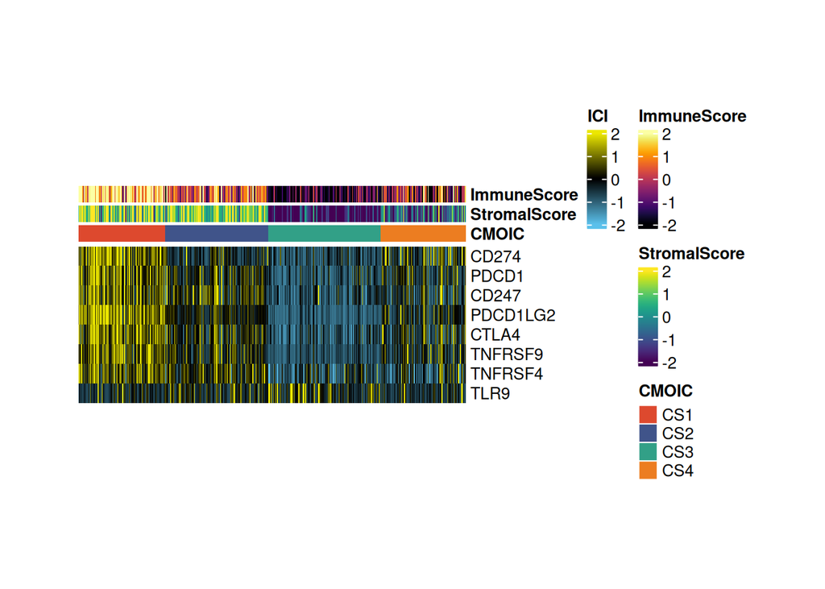

```r
# 设置颜色Set colors
clust.col <- c("#DD492E","#40548A","#32A087","#EC7D21")
heatmap.BlBkRd <- c("#54FEFF","#32ABAA","#125456","#000000","#510000","#A20000","#F30000")
blue <- "#5bc0eb"
gold <- "#ECE700"
cyan <- "#00B3D0"

# 添加ESTIMATE得分到注释 # Add ESTIMATE scores to annotation
# est.tcga已经是转置后的格式：行=样本，列=分数类型
# est.tcga is already transposed format: rows=samples, columns=score types
common_samples <- intersect(rownames(annCol.tcga), rownames(est.tcga))

if(length(common_samples) > 0) {
  annCol.tcga$ImmuneScore <- est.tcga[common_samples, "ImmuneScore"]
  annCol.tcga$StromalScore <- est.tcga[common_samples, "StromalScore"]
  annCol.tcga <- annCol.tcga[order(annCol.tcga$CMOIC),]
} else {
  warning("No sample matches found between annotation and ESTIMATE scores.")
  annCol.tcga$ImmuneScore <- 0
  annCol.tcga$StromalScore <- 0
}

# 确保注释数据有足够的差异 # Ensure annotation data has enough variation
if(length(unique(annCol.tcga$ImmuneScore)) < 2) {
  warning("ImmuneScore annotation has no variation. Adding minimal variation.")
  annCol.tcga$ImmuneScore <- annCol.tcga$ImmuneScore + rnorm(length(annCol.tcga$ImmuneScore), 0, 0.01)
}
if(length(unique(annCol.tcga$StromalScore)) < 2) {
  warning("StromalScore annotation has no variation. Adding minimal variation.")
  annCol.tcga$StromalScore <- annCol.tcga$StromalScore + rnorm(length(annCol.tcga$StromalScore), 0, 0.01)
}


# 重建热图的图例颜色 # Rebuild heatmap legend colors
annColors.tcga <- list() # 构建热图的图例颜色 # Construct the legend color of the heat map
annColors.tcga[["CMOIC"]] <- c("CS1" = clust.col[1],
                               "CS2" = clust.col[2],
                               "CS3" = clust.col[3],
                               "CS4" = clust.col[4])
# 使用基础颜色向量，但添加一些变化以避免断点值错误
annColors.tcga[["ImmuneScore"]] <- inferno(64)
annColors.tcga[["StromalScore"]] <- viridis(64)

## 热图1：免疫检查点基因表达 Heat map 1: immune checkpoint gene expression
indata <- log2(tpm[intersect(rownames(tpm),imm.targets),] + 1)
expr_data <- standardize.fun(indata[imm.targets,rownames(annCol.tcga)],halfwidth = 2) # 表达谱数据标准化 # Normalize expression profile data

# 确保数据有足够的差异用于热图 # Ensure data has enough variation for heatmap
if(length(unique(expr_data)) < 2) {
  warning("Expression data has no variation. Adding minimal variation for visualization.")
  expr_data <- expr_data + matrix(rnorm(length(expr_data)) * 0.01, nrow=nrow(expr_data), ncol=ncol(expr_data))
}


hm1 <- pheatmap(expr_data,
                border_color = NA, # 热图单元格无边框 # No borders around heatmap cells
                annotation_col = annCol.tcga[,c("CMOIC","StromalScore","ImmuneScore")],
                annotation_colors = annColors.tcga[c("CMOIC","StromalScore","ImmuneScore")],
                color = colorpanel(64,low=blue,mid = "black",high=gold),
                show_rownames = T, # 显示行名 # Show row names
                show_colnames = F, # 不显示列名 # Do not show column names
                cellheight = 12, # 热图高度固定 # Fixed heatmap height
                cellwidth = 0.6, # 热图宽度固定 # Fixed heatmap width
                name = "ICI", # 图例名字 # Legend name
                cluster_rows = F, # 行不聚类 # No clustering for rows
                cluster_cols = F) # 列不聚类 # No clustering for columns

#pdf("CheckPoint_heatmap.pdf",width = 10,height = 10)
hm1
```

```r
#dev.off()
```

## 8 热图2：肿瘤免疫微环境富集得分 Heatmap 2: Tumor Immune Microenvironment Enrichment Scores

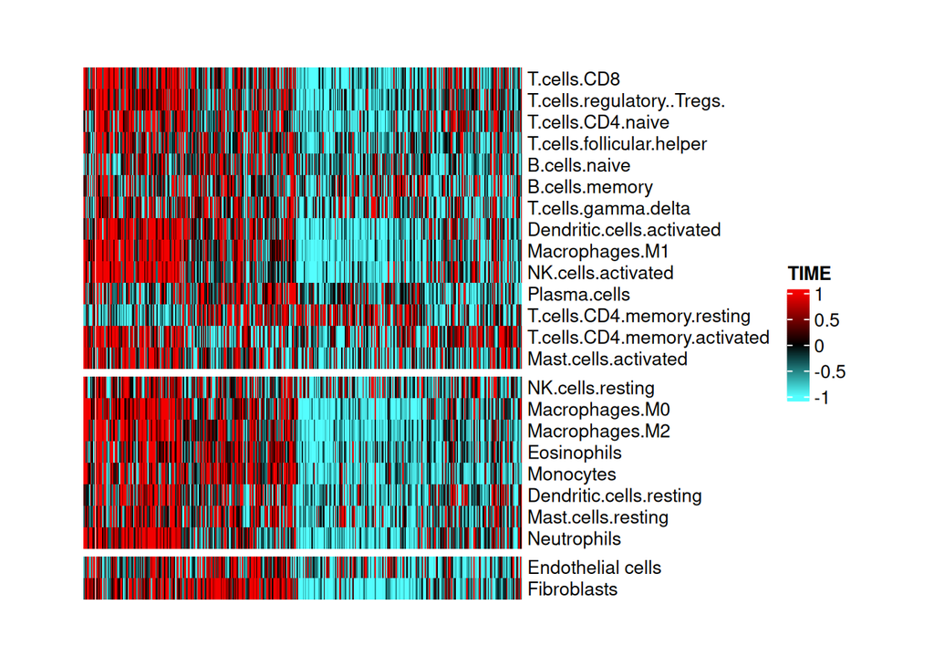

```r
heatmap_colors <- colorRampPalette(heatmap.BlBkRd)(64)

gsva_data <- standardize.fun(tcga.immune.gsva[immune.sig.ccr.order,rownames(annCol.tcga)],halfwidth = 1) # 富集得分标准化并排序

hm2 <- pheatmap(gsva_data,
                border_color = NA,
                color = heatmap_colors,
                gaps_row = c(14, 22), # 根据不同类别的免疫细胞分割 # Split based on different immune cell categories
                show_rownames = T,
                show_colnames = F,
                cellheight = 12,
                cellwidth = 0.6,
                name = "TIME",
                cluster_rows = F,
                cluster_cols = F)

#pdf("TIMEheatmap.pdf",width = 10,height = 10)
hm2
```

```r
#dev.off()
```

## 9 热图3：MeTIL得分 MeTIL score

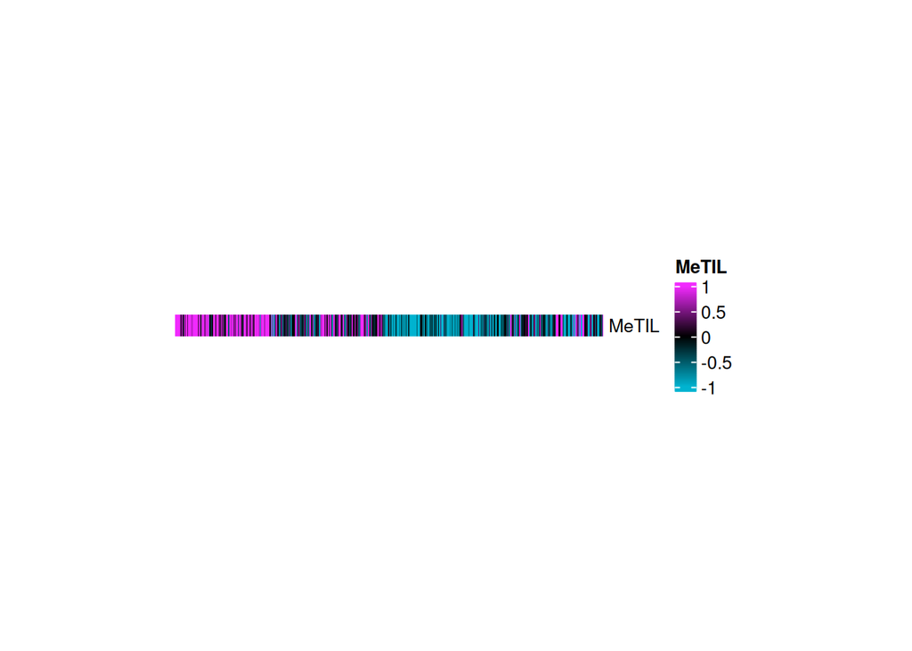

```r
# 使用现代的颜色插值方法 (2025年更新) # Use modern color interpolation (2025 update)
metil_colors <- colorRampPalette(c(cyan,"black","#F12AFE"))(64)

# 检查MeTIL数据是否有足够的差异 # Check if MeTIL data has enough variation
metil_data <- standardize.fun(t(annCol.tcga[,"MeTIL",drop = F]),halfwidth = 1)
if(length(unique(metil_data)) < 2) {
  warning("MeTIL data has no variation. Adding minimal variation for visualization.")
  metil_data <- metil_data + matrix(rnorm(length(metil_data)) * 0.01, nrow=nrow(metil_data), ncol=ncol(metil_data))
}

hm3 <- pheatmap(metil_data,
                border_color = NA,
                color = metil_colors,
                show_rownames = T,
                show_colnames = F,
                cellheight = 12,
                cellwidth = 0.6,
                name = "MeTIL",
                cluster_rows = F,
                cluster_cols = F)

#pdf("MeTILheatmap.pdf",width = 10,height = 10)
hm3
```

```r
#dev.off()
```

可以用下面的方法拼成一张图。也可以分别输出以上三个图到pdf文件，然后用Illustrator等软件打开后拼接。

You can use the following method to create a single image. You can also export the three images above to PDF files separately and then open them in software such as Illustrator to combine them.

```r
# 合并热图并输出 # Merge the heatmap and export
pdf("TIME.pdf",width = 10,height = 10)
draw(hm1 %v% hm2 %v% hm3,
     heatmap_legend_side = "right",
     annotation_legend_side = "right")
invisible(dev.off())
```

## 10 后期处理 Post-processing

输出的pdf文件是矢量图，可以用illustrator等软件打开，编辑图形和文字。

The output PDF file is a vector image and can be opened in software such as Illustrator to edit graphics and text.

## 11 关键更新要点 Key Updates Summary

- **依赖包现代化**：替换旧的 `estimate` 包为新的 `tidyestimate` 包，使用 `filter_common_genes` 和 `estimate_score` 函数替代旧的 `filterCommonGenes` 和 `estimateScore`
- **颜色函数更新**：替换过时的 `NMF:::ccRamp` 函数为现代的 `colorRampPalette`，使用 `grDevices::colorRampPalette` 确保新R版本兼容性
- **错误处理增强**：添加注释数据变异性检查，当数据缺乏变异性时自动添加最小随机扰动避免热图绘制错误
- **GSVA参数化改进**：使用新的 `gsvaParam` API 替代直接调用 `gsva` 函数，采用现代GSVA工作流程提高计算效率
- **Dependency Modernization**: Replaced the deprecated `estimate` package with the modern `tidyestimate` package, using `filter_common_genes` and `estimate_score` functions instead of the old `filterCommonGenes` and `estimateScore`
- **Color Function Updates**: Replaced the outdated `NMF:::ccRamp` function with modern `colorRampPalette`, using `grDevices::colorRampPalette` to ensure compatibility with newer R versions
- **Enhanced Error Handling**: Added annotation data variation checks, automatically adding minimal random perturbations when data lacks variation to prevent heatmap plotting errors
- **GSVA Parameterization Improvements**: Using the new `gsvaParam` API instead of direct `gsva` function calls, adopting modern GSVA workflow to improve computational efficiency